# Precarious Professionals: Layoffs and Gender Inequality in the Oil and Gas Industry

Converted from PDF `Bosky-LayoffsGenderInequality-2022-SF.pdf` · 29 pages · anchors: page `#pN`, block `#pN-bK`

Page 1

774 Social Forces 101(2)

#### **Layoffs and Gender Inequality**

### **Precarious Professionals: Layoffs and Gender Inequality in the Oil and Gas Industry**

Amanda Bosky*, Department of Sociology, University of Texas at Austin* Chandra Muller*, Department of Sociology, University of Texas at Austin* Christine L. Williams*, Department of Sociology, University of Texas at Austin*

organizational practices, professional work is becoming less stable. We examine the effects of this turbulence on gender inequality through a case study of layoffs in the oil and gas industry. Using a longitudinal survey that followed a cohort of recently hired scientists and engineers at a multinational oil and gas company from 2012–2016, we find that a major reduction-in-force during our study resulted in significant gender disparities in firm departures. Results indicate that about seventy percent of the gender gap in departures can be explained by underlying gender differences in the formal layoff criteria and workers’ experiences in the firm prior to layoffs, pointing to formal organizational processes as insidious mechanisms driving inequality. The firm stated that layoffs were determined by performance and skill set, but the actual attributes for surviving layoffs turned out to be more malleable and open to bias. Results suggest that the firm’s performance rating system may provide a pathway through which women’s relational disadvantages became formalized in seemingly bureaucratically neutral ways. Our findings illustrate how increasing insecurity in professional careers may disadvantage women and shed light on the organizational mechanisms that reproduce gender inequality in professional work today.

*Earlier versions of this study were presented at the annual meeting of the American Sociological Association, the Sociology Department Inequality Working Group, and the Bureau of Economic Geology at the University of Texas at Austin. The authors would like to thank Kristine Kilanski for research assistance in the design and implementation of early waves of data collection, Jennifer Glass and Eric Grodsky for helpful feedback and encouragement on previous drafts, and the editor and anonymous reviewers of Social Forces. We gratefully acknowledge the financial support of the Center for Financial Security Retirement and Disability Research Center at the University of Wisconsin-Madison, the Center for Demography and Ecology at the University of Wisconsin-Madison (through*

*Corresponding author: Amanda Bosky, University of Texas at Austin, Department of Sociology, 305 E 23rd St, A1700, RLP 3.306, Austin, TX 78712-1086, abosky@utexas.edu*

© The Author(s) 2022. Published by Oxford University Press on behalf of the University of North Carolina at Chapel Hill. All rights reserved. For permissions, please e-mail: journals.permissions@oup.com.

Social Forces 101(2) 774–802, December 2022

https://doi.org/10.1093/sf/soab169 Advance Access publication on 12 January 2022

Page 2

Layoffs and Gender Inequality 775

*grant P2CHD047873), and the Population Research Center at the University of Texas at Austin (through grants P2CHD042849 and T32HD007081). Any opinions,findings,and conclusions or recommendations expressed here are those of the authors and do not necessarily reflect the views of the funders.*

### **Introduction**

Since the 1970s, globalization, technological advancements, and deregulation have weakened job security for US workers. The standard employment relationship has eroded in the face of employers’ desires for cost reduction and flexibility in the new economy (Hacker 2008; Kalleberg 2009). For many US firms, mass layoffs, downsizing, and corporate restructuring have become standard organizational practices (Kalleberg 2009). Professional jobs once epitomized stability and security, yet professional workers are not immune from this increased uncertainty.

Growing insecurity poses implications for gender inequality in the labor market, which tenaciously persists even among professional workers. Recent studies suggest that career instability exacerbates gender inequality (Patterson, Damaske, and Sheroff 2017) and that layoffs can decrease women’s representation in management (Kalev 2014). As professional jobs grow more precarious, layoffs present an opportunity to investigate how instability reproduces gender inequality in high-status occupations. Layoffs are an ideal case for examining how structural conditions of insecurity may disparately impact women’s careers, as a focus on mass exits driven by macroeconomic conditions circumvents individualistic explanations that women are choosing to leave professional jobs (see Stone 2008).

Research has shown that effects of layoffs on gender inequality vary across firms depending on layoff rules and other organizational procedures (Kalev 2014). Organizational contexts shape the effects of downsizing on gender inequality because layoffs occur at the firm level. Gender disparities in layoffs could be due to underlying differences in worker characteristics relevant to layoff determinations (Kalev 2014) or outright discrimination at the point of layoffs (see Elvira and Zatzick 2002; but see Petersen and Saporta 2004). Investigating the organizational mechanisms that contribute to gender disparities in layoffs presents a challenge because scholars can rarely observe the layoff process as it unfolds.

In this article, we investigate organizational mechanisms of gender inequality through a case study of layoffs, using a longitudinal survey that followed a cohort of all recently hired scientists and engineers at a major oil and gas company from 2012–2016. Over the course of the study, oil prices fell by almost 80 percent, and the company went through multiple rounds of mass layoffs in which they cut nearly half of their technical workforce. We find that a large portion of our cohort left the company during layoffs, but women left at significantly higher rates: almost half of the women left, compared with around one-quarter of the men. Although these departures included those who left voluntarily as well as

Page 3

776 Social Forces 101(2)

those who were laid off, they all took place within the context of the company’s massive reduction in force in the face of an industry-wide shock. Those who left during this period were unlikely to transfer to other firms—most of which were also laying off workers during this period. We find that gender differences in the formal layoff criteria—performance and skill set—account for a significant portion of the gender gap in firm departures.

We argue that periods of mass layoffs provide an opportunity to view the consequences of gendered processes within an organization by compressing processes of inequality that may otherwise accumulate and unfold over time. We investigate these gendered organizational processes among a cohort of highstatus workers in highly compensated and credentialed positions. Focusing on a cohort of relatively homogenous professional workers hired at the same time effectively holds constant common individualized explanations for disparities in layoffs, such as job marginalization or seniority, and provides an ideal case for investigating organizational explanations. Our study builds on and complements Kalev’s (2014) organizational approach to managerial job loss, examining how organizational processes and layoff rules shape individual outcomes among non-managerial professional workers. Our findings elucidate the organizational mechanisms underpinning women’s continued disadvantages in professional careers.

### **Background**

#### *Organizational Mechanisms of Gender Inequality*

Sociologists have long recognized that workplaces play a crucial role in generating economic and social inequality. Firms link the macro and micro dimensions of work: societal forces affect workers through organizational processes, and firms’ actions impact their broader environments (Baron and Bielby 1980). An extensive tradition of organizational scholarship argues that organizations are infused with the power hierarchies of their historical and cultural contexts that generate inequality (Acker 2006; Dalton 1959; Kanter 1977a; Roscigno 2011; Tomaskovic-Devey and Avent-Holt 2019).

This view forms the basis of Acker’s (2006, 443) concept of organizations as inequality regimes, which she defines as “loosely interrelated practices, processes, actions, and meanings that result in and maintain class, gender, and racial inequalities within particular organizations.” Gender inequalities within a firm result from actions and interactions of individuals in the organization, but the characteristics of the organization influence the nature and extent of disparities by structuring relational processes of inequality (Gorman and Mosseri 2019; Reskin 2003). As organizational structures have evolved and diversified, identifying sources of inequality that persist within organizations is key for understanding gender inequality in the modern labor market, where organizational inequalities can easily translate into broader inequalities in career trajectories in the context of increased job insecurity.

Page 4

Layoffs and Gender Inequality 777

Theories of relational inequality conceptualize an organization as a bounded network of social relations (Tomaskovic-Devey 2014; Tomaskovic-Devey and Avent-Holt 2019). Relational explanations of inequality focus on how inequalities arise out of relations between people, through categorical distinctions connected to status and power (Ridgeway and Correll 2004; Roscigno 2011; Tomaskovic-Devey 2014). Gender status beliefs influence behavior and evaluations in contexts where gender is effectively salient, such as where actors differ in sex category or the activities involved are linked to stereotypic traits and abilities of a specific gender (Ridgeway 1997; Ridgeway and Correll 2004). Organizational contexts where gender is effectively salient may marginalize women in terms of whose voices are heard or sought out, who receives credit, and how responsibilities are apportioned—which can influence workers’ behaviors and perceptions in ways that legitimize gender disparities (see Byron and Roscigno 2014).

**Organizational Characteristics** Organizational characteristics shape relational inequality by framing the choices available to actors and moderating the influence of preferences and biases (Gorman and Mosseri 2019). Formal characteristics represent how an organization is supposed to function, whereas informal characteristics shape the actual dayto-day operation. Formal organizational processes may be the most insidious mechanisms contributing to gender inequality in the workplace because they are cloaked with the veneer of objectivity.

An organization’s formal structure delineates how work is defined and coordinated (Scott and Davis 2015). One source of gender inequality in an organization’s formal structure is the division of labor, which can segregate women and men into different types of work. Some studies suggest that the more fluid allocation of tasks within teams can benefit women (Kalev 2009; Smith-Doerr 2004), but others find that teamwork can obscure individual efforts and prevent women from receiving credit for their contributions (Heilman and Haynes 2005; Williams, Muller, and Kilanski 2012). Another aspect of formal structure that can influence gender inequality is an organization’s rules and practices; if rules provide clear guidelines and expectations, work processes are less subject to dynamics that disadvantage women. For instance, ambiguity regarding performance expectations and evaluation criteria can leave room for gender to influence evaluator’s perceptions (Heilman 2001), and “exceptions” to rules can be applied in gendered ways (Smith-Doerr et al. 2019). Further, rules outlining supervisors’ behavior can prevent supervisors from favoring workers with whom they have closer connections, which can disadvantage women when supervisors are predominantly men (Roth and Sonnert 2011; Neely 2018).

Informal characteristics include the organizational culture and informal structure. The informal structure consists of patterns of behavior and interactions among people in the organization, whereas organizational culture is a set of shared beliefs and values. The gender composition of a firm’s workforce shapes gender inequality within the organization through both its informal structure and culture (Gorman and Mosseri 2019). When an organization contains a high

Page 5

778 Social Forces 101(2)

proportion of men, men will engage in interactional dynamics that exclude and isolate women (Kanter 1977b); women’s lack of proficiency in the dominant cultural norms and values may hinder their success (Williams, Muller, and Kilanski 2012). The representation of women at higher and lower levels also influences women’s career progression within an organization (Gorman 2006; Gorman and Kmec 2009).

In this study, we elucidate how organizational characteristics shape gender inequality using a case study of departures among a cohort of professional science, technology, engineering, and mathematics (STEM) workers at a major oil and gas company during a major downturn in the industry. We argue that mass layoffs present an opportunity to observe organizational mechanisms that contribute to gender disparities by compressing processes of inequality.

#### *The Case of Layoffs*

Layoffs are key employment outcomes in increasingly precarious professional careers and can improve our understanding of how economic instability reproduces gender inequality (Kalev 2014). Layoffs not only have an obvious effect on workers’ individual career trajectories, but they also have repercussions for gender inequality within an organization and broader industry. Second, layoffs can cause subtle organizational gender biases and preferences to become salient because they compress processes of inequality that may otherwise only lead to perceptible gender disparities over time. The compression of these processes occurs because the institutional logic guiding layoffs underlies other areas of career development, as well. However, in contrast to organizational processes that have repeated tournaments (Rosenbaum 1979)—such as raises, promotions, or performance evaluations—layoffs represent a single winner-takes-all contest in which inequalities congeal at one point in time rather than accumulating across workers’ careers (see Gorman and Kmec 2009). Though a wealth of scholarship focuses on gender inequality in these tournament processes (see, e.g., Castilla 2008; Gorman and Kmec 2009; Smith-Doerr et al. 2019), mass layoffs provide a stark view of the consequences of systemic gender inequality and a discrete outcome for identifying organizational mechanisms.

**Sources of Gender Disparities in Layoffs** Gender disparities in layoffs within an organization may arise from two general sources: (1) discrimination at the point of layoffs and/or (2) preexisting gender differences in workers’ characteristics and experiences that disadvantage women in the layoff determination process. Discrimination can be difficult to identify because it generally transpires in contexts where it can remain obscured, or where employers have the greatest *opportunity* to discriminate (Petersen and Saporta 2004). For instance, Elvira and Zatzick’s (2002) study of a financial firm revealed racial disparities in layoffs and performance ratings but not wages or promotions, suggesting that inequalities depended on the managerial discretion and accountability involved in employment decisions. In our study, workers only received severance pay if they signed a termination agreement that included a

Page 6

Layoffs and Gender Inequality 779

release of discrimination claims against the company, which may have provided a unique opportunity to discriminate.

A gender gap in layoffs but not other indicators of career progression does not necessarily imply that individual biases of decision-makers are seeping into layoff decisions; disparities could also reflect the workings of a gendered organization (Acker 1990). For diversity and regulatory purposes, large companies generally monitor and standardize determinations related to wages or promotions to ensure decisions do not disparately impact women. Thus, even if women have worse experiences than men in the firm, relative equality in observable indicators of career progression could mask organizational processes that disadvantage women. Layoffs may unveil these processes by giving the firm less incentive to monitor disparate impacts (see Elvira and Zatzick 2002). In that case, women’s greater vulnerability to layoffs would be a product of the inequality regime rather than individual biases in layoff determinations.

In making layoff determinations, firms generally seek to reduce payroll burdens while retaining employees that will be valuable to ongoing business, and firms are increasingly using formal layoff rules to reduce legal exposure. The effectiveness of formalization in reducing inequality is not entirely clear (Dobbin, Schrage, and Kalev 2015; Elvira and Zatzick 2002; Kalev 2014; Reskin and McBrier 2000), and bias can persist in ostensibly fair procedures that can be used to justify discriminatory decisions (Byron and Roscigno 2014). *Biased* formalization will result in gender disparities if a firm’s layoff rules ignore underlying gender differences in the formal layoff criteria (Kalev 2014). Formal layoff rules tend to be based on individual measures of performance or workers’ structural attributes, such as position or tenure.

How formalization affects gender inequality may vary depending on organizational characteristics. If men are disproportionately the gatekeepers of local resources, they may engage in opportunity hoarding that benefits in-group members (men) and limits opportunities for out-groups (women) (Tomaskovic-Devey 2014). The salience of informal gendered processes may be exacerbated by rules that limit actors’ discretion, as decision-makers rebel against threats to autonomy (Dobbin, Schrage, and Kalev 2015). Further, formalization may matter less in smaller firms with flatter network organizations, as greater flexibility provides more routes to advancement and greater transparency provides natural accountability to organizational outsiders (Smith-Doerr 2004).

**Layoff Rules at the Organization in This Study** The firm in our study told workers that layoff determinations would be based on performance ratings and skill sets. Though skill set is somewhat ambiguous, a main way the company defined skill set was according to workers’ occupations and specializations. The company indicated that a high performance rating could compensate for an obsolete skill set because they were willing to retrain top performers; thus, performance might be considered the primary component. To the extent gender differences exist on these formal criteria, even an unbiased application would lead to gender disparities in layoffs.

Page 7

780 Social Forces 101(2)

The importance of performance ratings in the layoff rules will disadvantage women if they receive lower ratings than men on average, either due to bias in the evaluation process or systemic inequalities in work experiences that factor into evaluations. Though Kalev’s (2014) findings suggest that performance-based layoff rules may be relatively equitable, a sizeable body of research shows that women tend to receive lower performance ratings than men. In performance evaluations, women are consistently assessed as less capable and competent than men (Brewer et al. 2020; Correll et al. 2020). Women are particularly disadvantaged in male-dominated and technical fields; they are judged as less competent at male-typical tasks, and they may have to perform better than men to receive similar recognition (Cech 2013; Correll, Benard, and Paik 2007; Ridgeway 1997). If women end up performing female-typical tasks that require less technical skill, their contributions may be overlooked or devalued (Acker 1991; Fletcher 2001). A recent study showed that evaluations of women and men can also vary depending on the structure of the evaluative tool used, such as the number of categories in the rating system (Rivera and Tilcsik 2019). Even when women and men receive similar performance ratings, performance-reward bias may result in women receiving lower rewards (Castilla 2008; Joshi, Son, and Roh 2015).

To the extent workers’ skill sets are defined by occupational fields and specializations, this layoff rule effectively aligns with workers’ positions. Layoff rules based on positions generally disadvantage women due to gender segregation (Kalev 2014). The workers in our study fall into two broad occupations: geoscientists and engineers. Though both occupations are male-dominated, a higher proportion of women are geoscientists; thus, women are at greater risk of layoffs if geoscientists are more likely to lose their jobs than engineers. Gender segregation *within* these occupational groups in terms of specializations or across jobs and tasks might also disadvantage women (Leahey 2006; Levanon and Grusky 2016). For instance, Acker’s (1991) classic comparable worth study found that jobs objectively scored as comparable in value paid more when filled by men versus women.

Gender differences in assignments and opportunities for skill development could contribute to disparities in workers’ performance evaluations or skill sets. Compared to men, women tend to perform fewer developmental tasks (Benschop and Doorewaard 1998) and are more likely to engage in tasks that have little effect on their evaluation and career advancement (Babcock et al. 2017). Because skill development occurs through on-the-job experience, differential allocations of tasks and assignments may generate a skills gap between otherwise-similar women and men (Gorman and Kmec 2009). In fact, one study found that gender gaps in commissions among stockbrokers were the result of management assigning women inferior sales opportunities (Madden 2012). Beyond formal assignment allocations, supervisors may also steer men and women toward different career goals (Fernandez and Sosa 2005).

Considering the array of organizational processes that may contribute to higher layoff rates for women, we account for these processes to the extent possible in our analysis. The main way we can measure organizational processes

Page 8

Layoffs and Gender Inequality 781

is through their effects on workers’ characteristics and experiences in the firm prior to layoffs. This allows us to investigate organizational mechanisms by assessing gender disparities in workers’ pre-layoff characteristics and experiences and the extent to which they translate into disparities in layoffs. We supplement these analyses with workers’ open-ended survey responses to elucidate how organizational processes may contribute to women’s disadvantages.

### **Data and Methods**

#### *Research Setting and Data Collection*

Although the oil and gas industry is notorious for its sexism, in recent years it has embraced diversity as a goal, in part to address problems with retention (Williams, Kilanski, and Muller 2014). This was the case with the company in our study, a multinational oil and gas company that we call General Oil & Gas, or GOG (a pseudonym). When this study began in 2012, GOG was especially concerned about women’s attrition, a problem endemic to science careers in general (Glass et al. 2013). Frequent concerns were expressed about the impending “Great Crew Change,” or the U-shaped age distribution of the workforce characterized by many early-career hires, an aging leadership, and few mid-career scientists and engineers to step into leadership positions. Human relations professionals at the company wanted to understand how to better cultivate and retain their recent technical hires in preparation for anticipated retirements.

To identify factors associated with retention and attrition, we designed a survey to follow a cohort of scientists and engineers. Our sample was based on an email list that GOG provided of all US-based recent (last five years) geoscience and engineering hires; about 90% were early-career workers. The survey was written and administered by our research team without corporate oversight. Human resource representatives from GOG wrote an e-mail introducing us and encouraging employees to respond to the initial survey. The survey was administered five times at one-year intervals (from 2012–2016) to the cohort of scientists and engineers (population N = 360).<sup>1</sup> By definition, all members of the cohort were college educated—the engineers at least at the bachelor’s level and the scientists at the master’s and Ph.D. levels. They earned very high salaries, putting them in the top five percent of all income earners in the United States. They were also disproportionately white; most non-white employees were not US citizens and were often from oil-rich countries (e.g., Venezuela, Nigeria).

The questionnaire included items about topics such as job satisfaction, team and supervisor experiences, performance ratings, and roles at GOG. We also included open-ended questions to learn more about respondents’ employment experiences. For employees who left the firm, we asked about their reasons for leaving and subsequent employment. The survey yielded an 81% overall response rate in our first two waves combined, resulting in a sample of about 290 respondents. (Wave 1 non-respondents who answered in Wave 2 were given

Page 9

782 Social Forces 101(2)

extra background questions to fill in details collected in Wave 1.) Sample attrition increased across survey waves; among sample members (n = 290), response rates were 91%, 70%, 56%, 57%, and 51% across the five waves, respectively. Women’s response rates were around ten percentage points higher than men’s across all waves. At each wave, we requested updated employment and personal information, including alternate e-mail addresses for future follow-up.

*Measures for Multivariable Analyses* *Departure during Layoff Period.* Our dependent variable is a dichotomous measure of whether respondents left GOG after Wave 3, which captures the period in which layoffs occurred. We discern who has left the company in two ways. First, respondents reported if they had left GOG at each survey wave; about 40% of respondents’ departures were ascertained through survey responses. Because response rates were higher for women overall, more of women’s departures were obtained through the survey (45%) versus men’s departures (30%). Nonrespondents are counted as having left the company if their corporate email was returned as undeliverable when we administered the survey wave (indicating that they were no longer at the company). We cross-referenced determinations with information from online sources such as LinkedIn. About 60% of departures were ascertained through returned corporate emails; we still attempted to contact all respondents using alternate emails or websites such as LinkedIn.

Because most departures are captured through undeliverable emails, we do not know why every person left GOG. However, a few things give us confidence that our outcome reflects involuntary layoffs. First, we limit our measure of layoffs to employees who left during the mass layoff period. For the subset of departures captured through survey responses, all respondents said they left through the layoff process and received severance. Among this subset, about 75% characterized their layoff as involuntary. Part of the layoff process was that workers could volunteer for layoffs prior to determinations. Management still had to approve voluntary layoffs; if workers left outside of the layoff process, they would not receive severance pay. Subsequent employment rates were similar regardless of how respondents characterized the voluntariness of their layoff, with less than 30% reporting new employment within our survey period. This underscores the universally poor employment prospects across the industry during the downturn and suggests that most workers who left voluntarily were not leaving for other opportunities but may have been pushed out by layoff conditions.

**Worker Characteristics and Experiences prior to Layoffs** *Layoff Criteria.* GOG’s primary layoff criteria were performance and skill set. We asked respondents to report their most recent performance ratings at each wave. At GOG, performance is evaluated annually using a five-point scale, with a 1 being “exceptional,” 3 “average,” and 5 “unacceptable” (no respondents reported a rating of 5, so the range in our sample is 1–4). Supervisors rank team members based on performance, and employees are then rated on a bell

Page 10

Layoffs and Gender Inequality 783

curve distribution, with no more than 10 percent rated as “exceptional” (1) and most rated as “average” (3). We measure worker performance prior to layoffs using an average of performance ratings from Waves 1–3. Because of attrition across waves, this measure is based on three ratings for 44% of the sample, two ratings for 25% of the sample, and one rating for 32% of the sample. Alternate specifications yield similar results; however, this measure incorporates the entire history of performance available for each worker. Ancillary analyses indicate that more recent ratings are more strongly related to layoffs but that the average across waves is more predictive than any one wave’s ratings. This supports our approach of using all available ratings data but suggests that incomplete ratings histories may attenuate the explanatory power of the measure.

A main way the company defined skill set was professional background and training. Following how the firm refers to the technical workforce, we use job titles to categorize respondents as engineers or geoscientists. Though workers have different specializations and positions within these fields, further distinctions would require us to speculate as to the value GOG assigned to different specializations. Engineers dominate our sample, and the distinction between job fields is important for this study because a relatively larger share of geoscientists is women.

*Interactional Dynamics and Value to Organization.* In addition to the formal layoff criteria, we assess workers’ experiences at GOG prior to the layoff period to shed light on organizational processes that might contribute to gender differences in layoffs. We include indicators that relate to two aspects of workers’ experiences that could influence layoff determinations. The first aspect is interactional dynamics, which we measure using workers’ relationships with their supervisors and the quality of their team experiences. The second aspect is value to the organization, which we measure using workers’ career development, experience in supervisory positions,and how central their teams are to generating profit. All measures are constructed using items from Waves 1 and 2 of the survey.

Relationship with supervisor, quality of team experiences, and career development are measured using indexes that combine multiple survey items. The components and alphas for each index variable are included in table 1. In Waves 1 and 2, we asked workers about their experiences and opinions regarding different dimensions of work at GOG; the components of the index variables are based on averages of the two waves of responses. To create the indexes, we identified survey items that related to each concept, and then we used confirmatory factor analysis to validate our categorizations. Finally, we averaged the items and standardized the indexes to a mean of 0 and standard deviation of 1. In addition to the index variables in table 1, we use a single item to measure how central a worker’s team is to generating profit for GOG, as this item was conceptually distinct.<sup>2</sup> The final measure is a dichotomous indicator of experience in a supervisory position; this includes current and former positions and may include experience outside of GOG for some respondents.

Page 11

784 Social Forces 101(2)

**Table 1. Composition of Index Variables**

**Relationship with supervisor** (*α* = .88)

I am comfortable talking with my supervisor about technical issues

I am comfortable talking with my supervisor about my career goals

My supervisor gives me good assignments

My supervisor has given me good opportunities to present my work to GOG

management

My supervisor makes sure I have the resources I need to accomplish my goals

Level of feedback on job performance<sup>a</sup>

Accuracy of performance evaluation<sup>a</sup>

**Career development** (*α* = .79)

Sense of personal accomplishment from my work<sup>a</sup>

The level of challenge in my work<sup>a</sup>

How well assignments match career goals<sup>a</sup>

Prospects for promotion<sup>a</sup>

**Quality of team experiences** (*α* = .65)

Nearly all new research or other technical ideas are given adequate consideration

Nearly all new ideas for improving communication, organization, and other

non-technical ideas are given adequate consideration

There is very little or no cooperation among the team members (reversed)

I regularly voice my ideas in team meetings

Team members seek my opinion on important issues

aThese items asked respondents to indicate their satisfaction with these aspects of their jobs. All other items asked respondents to indicate their agreement with the statements. All items have Likert type responses with no neutral option and a range of 1-4.

#### *Additional Measures for Descriptive Analyses*

We include information on several indicators of career progression at GOG, to assess how they compare to layoffs. All measures are based on workers’ selfreports. We have measures of salary and promotions, which are supposed to be based on a standardized scale/schedule. The number of promotions indicates promotions that occurred between waves 1 and 3 (range of 0-2). We also have a measure of perceived career progression, which is a categorical indicator of whether a worker’s career has progressed slower than average, about average, or faster than average compared with their peers. Finally, we report basic demographic and work characteristics for the sample, including age, race, family structure, and tenure at GOG. For parsimony, we do not include these measures in our models; ancillary analyses indicate that including these measures does not affect our results.

#### *Supplementary Data from Open-Ended Survey Responses*

In addition to the quantitative survey data, we draw on representative quotes and themes from open-ended survey responses to highlight possible mechanisms

Page 12

Layoffs and Gender Inequality 785

related to patterns we observe. We began by coding open-ended responses deductively based on the measures in our quantitative analyses, and then we identified themes within and across codes that helped explain the patterns. Some open-ended survey responses were standalone items, whereas others allowed respondents to provide additional information about closed-ended responses; overall, almost 85% of respondents provided at least one open-ended response across survey waves. However, we make no claims for generalization, as the goal in using these responses is to suggest possible explanations for the quantitative findings that are consistent with existing literature and theory.

#### *Analytic Plan*

We investigate organizational mechanisms of gender inequality at GOG through a series of analyses that describe gender differences among workers and assess their contribution to gender disparities in layoffs. First, we examine patterns in men’s and women’s rates of departure from GOG before and during the layoff period. Next, we compare men and women descriptively to assess gender differences in layoff criteria, worker experiences, and career progression prior to layoffs. We then estimate logistic regressions predicting job departure during the layoff period, focusing on the gender gap. We conduct logistic regressions rather than survival analyses because we do not have departure dates for most workers. We evaluate possible mechanisms by first including each independent variable in separate logistic regression models and then combining all measures in the full model. In addition, we estimate Kitagawa-Blinder-Oaxaca<sup>3</sup> (KBO) decompositions based on each regression model. Our final statistical analysis assesses the unique contribution of each measure to the gender gap in departures using a detailed KBO decomposition. Throughout the statistical analyses, we discuss the open-ended survey responses to elucidate possible organizational processes.

For our primary analyses, we restrict our sample to workers employed at GOG when the oil bust occurred, as they would have been exposed to layoffs. This drops approximately thirty respondents who left GOG prior to Wave 3, resulting in a final analytic sample of about 260 workers. We handled missing data on independent variables with multiple imputation using chained equations (m = 10 imputations). Rates of missing were 5% or below on all independent variables other than performance ratings, which had 8% missing. Results are consistent using single imputation or listwise deletion. All analyses include probability weights that account for selection into the analytic sample and the aggregation of multiple waves of data. First, these weights account for women’s slightly higher response rates. To better estimate the effect of the economic downturn on departures, the weights also account for workers’ propensity of leaving GOG prior to the downturn (based on key demographic characteristics, job satisfaction, and performance ratings at Wave 1). Finally, the weights account for the fact that most measures are averages across waves, such that respondents with more waves of data contribute more information to the estimates.<sup>4</sup> Unweighted analyses yield similar results.

Page 13

786 Social Forces 101(2)

### **Results**

#### *Gender Differences in Job Departures before and during Layoffs*

Figure 1a shows how the gender composition of the cohort at GOG changed over our survey period and multiple rounds of layoffs (population N = 360); for comparison, figure 1b shows a graph for survey respondents only (n = 290). The price of oil was high ($110/barrel) when we began the study in 2012, and it remained high for the first few years. By Wave 4, in 2015, oil prices had dropped by over half (below $50/barrel). A 10% reduction in professional technical staff at GOG occurred that spring, and an additional 15% reduction was scheduled for the fall. In 2016 (Wave 5), oil prices dropped to their twenty-year nadir, and two additional rounds of layoffs occurred at GOG.By the last wave of our survey, almost 45% of workers in the cohort had left GOG. The cohort already had a high proportion of men when our study began, reflecting the male-dominated nature of the oil industry and physical science occupations. Mass layoffs left the cohort even less diverse, reducing the proportion of women workers from 28% to 23% over a relatively short period of time.

#### *Gender Differences in Workers’ Pre-Layoff Characteristics*

We begin our investigation of the gender gap in departures during the layoff period by assessing gender differences in the layoff criteria, worker experiences, and career progression prior to layoffs. Table 2 presents weighted bivariate statistics for workers in our sample, highlighting significant differences between men and women. Correlations between all measures of worker characteristics and experiences are presented in table 3.

In table 2, gender differences on the formal layoff criteria point to biased formalization as a likely source of gender inequality in layoffs; even assuming an objective application of these basic criteria, we would expect a gender gap in layoffs. First, women’s average performance ratings are significantly worse than men’s. In the open-ended responses, workers consistently expressed concerns about the performance ratings system. Because performance ratings were based on a personnel ranking policy, the requirements for receiving a high rating were nebulous, as illustrated by one woman’s response:

I met or exceeded every expectation in my performance goals and *. . .* was ranked a 4 [low]. My supervisor was very candid that this is a result of the forced ranking policy.

Page 14

Layoffs and Gender Inequality 787

**Figure 1. Gender composition of cohort still employed at GOG across survey waves. a. Full cohort (including survey non-respondents). b. Respondents.**

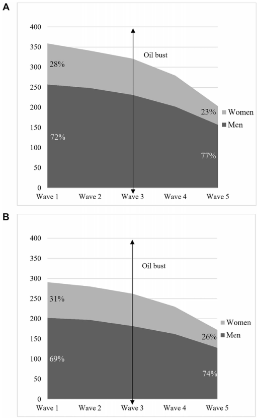

NOTE: figure/graphic rendered as an image from the PDF; its content is not machine-readable text. Caption (if any) follows as the next block.

Page 15

788 Social Forces 101(2)

**Figure 2. Gender differences in job departures at GOG.** <sup>∗∗∗</sup>*p* *<* **.001,** <sup>∗∗</sup>*p* *<* **.01,** <sup>∗</sup>*p* *<* **.05,**

∧*p* *<* **.1 (indicates significant gender difference in proportion).**

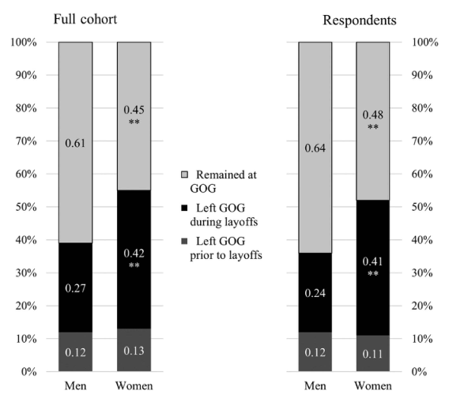

NOTE: figure/graphic rendered as an image from the PDF; its content is not machine-readable text. Caption (if any) follows as the next block.

The structure of the ratings system may have made it particularly difficult for women to achieve the highest ratings, as they were being ranked by and against mostly men. In addition, individualized performance plans further compounded workers’ difficulties in ascertaining and meeting expectations for a high rating; individualized goals make progress difficult to compare and evaluate across workers, and unclear requirements leave more room for supervisor discretion (Williams, Muller, and Kilanski 2012).

As opposed to the individualized nature of performance ratings, job field represents a structural source of disadvantage for women. Geoscientists should experience higher layoff rates because their positions are less integral to the continued operation of the firm during times of constraint. Though, it is also possible that geoscientists may be targeted for layoffs because they are older and earn higher salaries compared with engineers. Beyond structural disadvantages, the open-ended responses underscored power differentials between scientists and engineers that affected geoscientists’ career development. Supervisors were more likely to be engineers than scientists, and one man highlighted how this

Page 16

Layoffs and Gender Inequality 789

**Table 2. Weighted Bivariate Statistics for Workers Exposed to Layoffs**

[output not shown]

NOTE: table converted from PDF layout to HTML text; cell boundaries are reconstructed. See PDF if exact alignment matters.

∗∗∗*p <* .001 ∗∗*p <* .01 ∗*p <* .05 ∧*p <* .1 (indicates significant gender difference in means)

Page 17

790 Social Forces 101(2)

**Table 3. Correlations between Measures of Worker Characteristics and Experiences**

[output not shown]

NOTE: table converted from PDF layout to HTML text; cell boundaries are reconstructed. See PDF if exact alignment matters.

impacted teams: “Geoscientists are looked upon as second class citizens to engineers. Engineers generally get all of the credit and rewards for things that have been done as a team.” This sentiment was echoed by other scientists, who found it difficult to receive recognition or communicate training needs because supervisors had little geologic knowledge. Because skill sets encompass more than the engineer-scientist divide, the gender difference in job field likely underestimates gender differences in skill sets, as women tend to have lowerstatus specializations and fewer opportunities for skill development in critical areas.

Examining gender differences beyond the formal layoff criteria can provide a glimpse into organizational processes underlying gender differences in layoffs, which may operate as direct mechanisms or indirectly through the formal criteria. In terms of interactional dynamics, women report worse relationships with their supervisors—most of whom are men. In fact, about 90% of workers in our sample had supervisors who were men. Women are also consistently disadvantaged on measures that may proxy workers’ value to the organization, though women’s poorer career development is the only statistically significant gender difference. The correlations in table 3 show how these measures relate to the formal layoff criteria and to each other. As we would expect, job field is correlated with structural disadvantages within the firm: geoscientists are less likely to have supervisory experience and are on teams less central to generating profit. Performance ratings are most correlated with workers’ relationships with their supervisors and least correlated with structural factors. The low correlation between the two layoff criteria suggests these criteria reify two distinct sources of disadvantage for women within the organization; one is more structural, and the other is more individual and relational.

Page 18

Layoffs and Gender Inequality 791

The open-ended responses provide additional insight into the relationships between formal and informal organizational processes and how these dynamics might disadvantage women. One common theme in workers’ responses was that performance ratings were too dependent on teams—who was on your team, who your supervisor was, and how assignments were apportioned among team members. Workers emphasized the importance of your immediate supervisor, as they differed in their approaches to ratings and interactions with their team members. Assignment to higher-value assets made it easier to make large contributions and receive higher ratings; high performers were, in turn, more likely to be assigned to higher-value assets. Considering that women report worse relationships with supervisors and poorer career development, the importance of these factors in the performance ratings process may partially explain why women generally received lower ratings. The experiences of workers at GOG reveal how teamwork can harm women under some circumstances because teams essentially constitute smaller bounded networks of social relations within organizations, generating hyper-localized relational inequalities. The more fluid division of labor and the within-team performance rankings system meant that a worker’s opportunities and rewards were apportioned in relation to other members of their team and at the discretion of their supervisor; therefore, the identities and interactions of the people on a team influenced how equitably these processes operated.

Among indicators of career progression in table 2, we see no significant gender differences in promotions or salaries. Yet, women still perceive slower career progression, suggesting qualitative differences in men’s and women’s career trajectories that may be concealed by parity in promotions and salary. The open-ended responses indicated that career advancement in the firm depended on workers’ performance ratings and assignments, both of which are tied to supervisors. Thus, women’s poorer performance ratings, career development, and supervisor relationships may reflect the qualitative differences in career trajectories that promotions and salaries do not capture. Workers noted that supervisors varied in how often they gave promotions and how active they were in helping workers advance. One man phrased it bluntly: “Career progression is dependent on the attitude of the day of the manager.” Though promotions were supposed to occur on a schedule, people on high-profile teams or the managerial career track were generally promoted faster; men are more likely to fall into those categories than women. Some women directly stated that men got promoted faster, and one man emphasized proactive communication in receiving timely promotions:

I was proactive in receiving my first promotion when I was first eligible; this allowed my subsequent promotions to come earlier than later. My peers who did not actively communicate with their boss about promotion status are finding themselves lagging behind.

A few women opined that they spoke up too late about overdue promotions, but a “proactive” approach may not benefit women if it comes across

Page 19

792 Social Forces 101(2)

as aggressive—a stereotypically masculine characteristic. Men also discussed the importance of networking and relationships with supervisors, which may advantage men because supervisors and successful colleagues also tend to be men.

Workers in our sample had only been employed at GOG for an average of five years; because gender disparities in career progression tend to widen over time, it may be too early in workers’ careers for perceptible inequalities to emerge. The layoffs provide a chance to observe the effects of the organizational processes that contributed to the differences in women’s and men’s work experiences that are present even this early in their careers.

#### *Analysis of the Gender Gap in Job Departures during Layoffs*

How much of the gender gap in departures during layoffs can be explained by gender differences in the layoff criteria and other pre-layoff characteristics and experiences? Table 4 presents average marginal effects (AMEs) from logistic regressions predicting departures during the layoff period. The AMEs can be interpreted as an average change in the probability of departure; for example, the baseline model shows that women had about an 18 percentage point higher probability of leaving than men (P(departure | women)-P(departure | men) = AME [.44-.26 = .18]). Considering correlations among the predictors, we assess each measure individually before presenting the full model. In addition to the AMEs, each model includes the percentage of the gender gap explained in a KBO decomposition. Models 2 and 3 show that the formal layoff criteria significantly predict workers’ departure during layoffs. Geoscientists have a 15 percentage point higher probability of leaving compared with engineers, and one point worse on the performance ratings scale translates into a 22 percentage point higher probability of leaving. Job field does not explain a significant portion of the gender gap, whereas women’s lower performance ratings alone explain about 45% of the gap. Among other measures of worker characteristics and experiences, women’s worse relationships with supervisors (Model 4) and poorer career development (Model 6) each explain a significant portion of the gender gap in departures.

Together, the measures explain about 70% of the gender gap in Model 9, indicating that pre-layoff gender differences translated into gender disparities in departures during layoffs. Among these measures, performance ratings and job field are the most objective indicators we have of the formal layoff criteria. Because skill set is an ambiguous criterion, it is unclear how management may have used that ambiguity to differentiate between workers with similar performance and job fields. Thus, the other measures could have contributed to the gender gap in layoffs through their correlation with performance or job field, or by further distinguishing between workers in layoff determinations.

Page 20

Layoffs and Gender Inequality 793

**Table 4. Average Marginal Effects from Logistic Regressions Predicting Job Departures during Layoff Periods**

**n** = **260 (1) (2) (3) (4) (5) (6) (7) (8) (9)**

Female 0.179 ∗∗ 0.159 ∗ 0.121∧ 0.169 ∗ 0.179 ∗ 0.150 ∗ 0.172 ∗ 0.175 ∗ 0.0748

(0.0690) (0.0689) (0.0637) (0.0675) (0.0684) (0.0672) (0.0694) (0.0691) (0.0614)

*Layoff criteria*

Job field: geoscientist — 0.146 ∗ — — — — — — 0.158 ∗

(0.0603) — — — — — — (0.0610)

Average performance

rating — — 0.218 ∗∗∗ — — — — — 0.225 ∗∗∗

— — (0.0503) — — — — — (0.0512)

*Interactional*

*dynamics*

Relationship with

supervisor — — — −0.0401 — — — — 0.0567

— — — (0.0319) — — — — (0.0364)

Quality of team

experiences — — — — −0.0307 — — — 0.0128

— — — — (0.0331) — — — (0.0338)

*Value to*

*organization*

Career development — — — — — −0.0809 ∗ — — −0.115 ∗∗

— — — — — (0.0315) — — (0.0382)

Ever worked in

supervisory position — — — — — — −0.0927 — −0.0612

— — — — — — (0.0983) — (0.0863)

Continued

Page 21

794 Social Forces 101(2)

**Table 4. Continued**

[output not shown]

NOTE: table converted from PDF layout to HTML text; cell boundaries are reconstructed. See PDF if exact alignment matters.

Page 22

Layoffs and Gender Inequality 795

**Table 5. Detailed Decomposition of the Gender Gap in Job Departures during Layoff Periods**

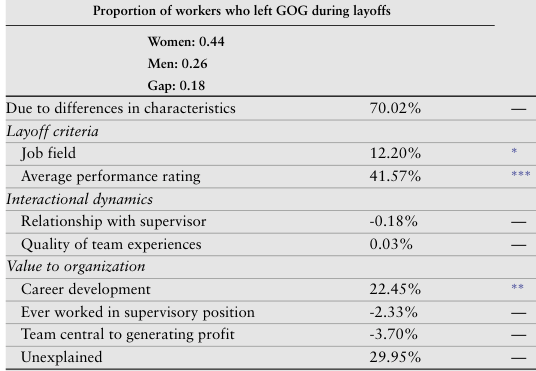

NOTE: complex table shown as an image of the PDF; the text below is a rough machine extraction and may be mis-aligned.

**extracted text (unreliable layout)**

Note: Results from a KBO decomposition based on the logistic regression model in Table 4, Model 9. ∗∗∗*p <* .001 ∗∗*p <* .01 ∗*p <* .05

Altogether, measurable pre-layoff gender disparities at GOG can explain almost three-fourths of the gender gap in job departures during layoff periods. The unexplained portion in our decomposition is likely a combination of gender differences in unmeasured pre-layoff characteristics, such as more fine-grained gender segregation, and gender discrimination in layoff determinations.

The fact that most of the gender gap in layoffs can be explained by workers’ pre-layoff characteristics and experiences provides substantial support to the premise that layoff patterns reflect the local inequality regime. Workers’ perspectives and experiences help illustrate how gender permeates organizational

Page 23

796 Social Forces 101(2)

processes at GOG, resulting in subtle but pervasive disadvantages for women. Gender disparities are veiled by ostensibly meritocratic procedures and relative parity in salaries and promotions, yet the disadvantages are perceptible to the women who experience them. In examining the open-ended responses, the difference between men and women in their *discussion* of gender was striking. Women not only identified specific instances of gender inequality, but they also incorporated gender into discussions of their experiences more generally—saying things like “as a woman,” or mentioning the gender of co-workers. On the other hand, men simply never acknowledged gender, at all. Men expressed perceptions of unfairness, but these inequities were attributed to gender-neutral factors like personality or social relationships. Women bluntly discussed the difficulties of being a woman at GOG because it was a “man’s world.” Women said they had a hard time being taken seriously, felt supervisors were not supportive of their goals, and were left out of meetings and conversations where business decisions were made. Apart from any effects gender had on individuals’ career progression, women clearly felt the weight of the gendered climate at the firm.

### **Discussion**

Despite strengthening individual and corporate commitments to diversity and gender equality in the United States, women continue to fare worse than men in professional careers. We argue that layoffs present an opportunity to investigate the organizational mechanisms that reproduce gender inequality by compressing and revealing gendered organizational processes. An intense period of layoffs during our longitudinal study of STEM professionals at an oil and gas company allows us to not only document gendered patterns in layoffs but also speak to possible organizational processes driving the patterns. We find that women left the company at significantly higher rates than men during the layoff period, and gender differences in workers’ pre-layoff characteristics and experiences account for most of the gender gap in departures. Our findings point to formal organizational processes as insidious mechanisms of inequality, and workers’ open-ended responses suggest explanations consistent with theories of relational inequality as to how the formal rules and structure of work may reify gender inequalities in the firm’s informal structure and organizational culture.

We find evidence of biased formalization (Kalev 2014), such that formal layoff criteria perpetuate gender inequality due to underlying gender disparities on relevant employment characteristics. Women’s lower performance ratings, poorer career development, and concentration in a lower-status field explain about 75 percent of the gender gap in layoffs, suggesting that the layoffs largely reveal existing biases in organizational processes at GOG. The importance of supervisors to performance ratings and performance-related processes such as assignments and skill development highlights a possible pathway through which women’s relational disadvantages might become formalized in seemingly bureaucratically neutral ways.

These findings suggest that male supervisors may have engaged in opportunity hoarding to give other men better opportunities or ratings despite—or perhaps,

Page 24

Layoffs and Gender Inequality 797

because of—the rigid rules governing performance evaluations at GOG (see Dobbin et al. 2015; Tomaskovic-Devey 2014). Though women reported similar team experiences to men, the male-dominated teams and attendant dynamics held gendered consequences for career development and the personnel ranking system. The team structure, power given to supervisors, and importance of performance ratings for advancement in the context of a large bureaucratic corporation meant there was little chance for the flexibility or transparency identified by Smith-Doerr (2004) as key components of gender equity in biotech firms.

Research on layoffs’ effects on managerial diversity has found that rules based on performance evaluations are relatively equitable toward women (Kalev 2014). Our study presents contrasting findings among non-managerial workers, showing that gender inequalities in performance assessments account for much of the gender gap in layoffs among a cohort of STEM professionals. The firm in our study espoused a commitment to diversity; they wanted to recruit and retain more women workers and had formal procedures to mitigate gender disparities in career progression. Layoffs may have revealed the limits to this commitment, allowing gender inequalities with potentially long-reaching consequences for workforce diversity under the guise of corporate necessity. However, without this commitment to diversity during normal economic conditions, gender disparities may have been even worse.

The patterns we find in gender disparities across work outcomes are consistent with Elvira and Zatzick’s (2002) findings regarding patterns of racial inequality: disparities in layoffs and performance, but not wages or promotions. However, parity in wages and promotions at GOG was masking gender differences in workers’ experiences; women reported worse relationships with their supervisors, poorer career development, and slower perceived career progression. Thus, the organizational processes driving gender inequality within the firm were always there, but they only translated into observable gender disparities in outcomes during layoffs. The layoff process may have provided a distinct opportunity for organizational biases to emerge, as workers could not complain of disparate treatment if they wanted to receive their much-needed severance packages.

We can explain much of the gender gap in departures, but we cannot know how GOG management made individual layoff decisions. The gender differences on variables in our data could reflect observable distinctions between workers on relevant layoff criteria, which may have been applied objectively or used as *post hoc* justifications for discriminatory decisions. Further, some measures could simply be capturing systemic sexism within the organization. Though our KBO decomposition apportions the gender gap among variables in our model, it cannot establish causality and can be sensitive to model specification. Ancillary analyses indicate that the portion of the gap attributed to the layoff criteria is robust to a host of demographic and career indicators, but we cannot account for characteristics and processes outside the scope of our data. Deciphering exactly how women’s organizational disadvantages translate into layoffs is not particularly important in the context of this study; rather, *that* these

Page 25

798 Social Forces 101(2)

disadvantages translate into layoffs suggests that layoff patterns largely reflect systemic gender inequality within the firm. To the extent that systemic inequality resulted in gender differences on the formal layoff criteria, these differences imbue women’s higher layoff rates with a false sense of legitimacy.

Though this study focused on layoffs, our findings may shed light on organizational mechanisms underlying gender disparities in long-term career trajectories because layoffs compress processes of inequality. Layoffs reflect the local inequality regime and make gender differences within the organization salient at a discrete point in time, as opposed to disparities manifesting slowly and cumulatively across workers’ careers. The patterns in layoffs indicate who is vulnerable at decision points and who is likely to succeed within the organization by revealing organizational biases and preferences. Our study presents a unique case for examining gender inequality because many mechanisms that contribute to gender disparities in career progression are effectively “held constant.” The individuals in the cohort are all highly skilled, professional STEM workers; were hired by the same company within a five-year period; and have similar demographic characteristics. Yet, we still find significant gender differences among our homogenous sample—which suggests organizational, rather than individual, explanations for these differences.

Our findings also speak to issues of gender inequality within STEM occupations specifically. Despite efforts to increase women’s representation in STEM, recent research has highlighted the persistent paucity of women at high levels (Cech and Blair-Loy 2010) and high exit rate of women from STEM professions, especially engineering (Glass et al. 2013; Hunt 2016). In contrast to explanations of women leaving voluntarily or being pushed out of STEM professions, our findings implicate layoffs as a mechanism contributing to women’s long-term attrition. The gender composition of our cohort dropped from 28% to 23% women, suggesting that job instability may help explain the dearth of women in high-status positions in the oil and gas industry (see Eagly 2007). The workers who remained at the company will likely fill management positions in the future, but GOG disproportionately culled its already small pool of women candidates (see Kalev 2014).

This study employed longitudinal data on a cohort of professional workers within a single firm. This narrow focus avoided confounding issues related to occupational and tenure disparities, but our cohort did not represent all workers at GOG or even all professional workers. Ancillary analyses indicate that some gender differences were more pronounced among engineers than geoscientists, so patterns of gender inequalities may vary depending on organizational position. Research using a broader sample of workers can illuminate how organizational processes of inequality vary across positions. In addition, we may be capturing a time in workers’ careers when gender differences in performance ratings are particularly large. Status characteristics may influence performance ratings more among workers with a shorter history in the firm. This is also when many workers are having children, so parental leave or responsibilities may differentially impact men’s and women’s work experiences. Future research might examine

Page 26

Layoffs and Gender Inequality 799

how parenthood shapes gender disparities in layoffs or whether the sources and extent of organizational gender inequality vary for older workers.

Sample size limited our analysis, but we still found striking and consistent gender differences among this relatively small cohort of workers. However, our sample contained only a small number of racial and ethnic minorities, so our findings mostly relate to white women’s disadvantages and vulnerability to layoffs. Future research with a larger or more diverse sample is needed to build intersectional understanding of gendered processes, as previous research has highlighted the complex nature of inequality in STEM careers (Alegria 2019; Alegria and Branch 2015). Our measure of layoffs was limited by our inability to discern the reason for most departures. Available data suggested that most layoffs were involuntary, and management had to approve voluntary layoffs; thus, we believe the patterns are driven by firm decisions. Even if we could distinguish voluntary layoffs, workers had to volunteer before determinations were made; it would be impossible to know whether they would have been laid off involuntarily. If volunteers were less likely to be laid off involuntarily, then our results may be conservative in terms of the explanatory power of the layoff criteria.

Our focus on layoffs adds an important dimension of gender inequality to existing literature and demonstrates how companies may ultimately undermine women’s career trajectories. Layoffs provide a glimpse at organizational mechanisms that perpetuate gender inequality and illustrate how increasing insecurity in professional careers may disadvantage women. The findings in this study suggest that periods of corporate downsizing can reveal the organizational processes that reproduce gender inequality—processes that may remain veiled during “boom” times.

### **Notes**

1. We round sample numbers to the nearest 5 for confidentiality. 2. The survey question asked respondents to indicate the extent of their agreement with the following statement: “My team is central to generating profit for GOG.” 3. Though commonly known as a Blinder-Oaxaca decomposition, this terminology acknowledges earlier work by sociologist Evelyn M. Kitagawa (1955). 4. The final weights are the product of: the inverse probability of survey response, the inverse probability of leaving prior to layoffs, and the number of waves of data available.

### **About the Authors**

**Amanda Bosky** is the content editor at Bloomboard, Inc. and a lecturer of sociology at the University of Texas at Austin. Her research investigates the roles of education, organizations, and occupations in reproducing or disrupting

Page 27

800 Social Forces 101(2)

economic inequalities; most of her work focuses on gender inequality in the labor market.

**Chandra Muller** is a professor of sociology at University of Texas at Austin. She studies the implications of inequalities in education for later life outcomes, including work and health. She is a principal investigator on the High School and Beyond Midlife Follow-up Study, a longitudinal survey of Americans followed from adolescence through their late 60s.

**Christine L. Williams** is a professor of sociology at The University of Texas at Austin where she studies gender and workplace inequality. Her recent book is *Gaslighted: How the Oil and Gas Industry Shortchanges Women Scientists* (University of California Press 2021).

### **References**

Acker, Joan 1990. “Hierarchies, Jobs, Bodies: A Theory of Gendered Organizations.” *Gender & Society*

4(2):139–58. Acker, Joan 1991. *Doing Comparable Worth*. Philadelphia: Temple University Press. Acker, Joan 2006. “Inequality Regimes: Gender, Class, and Race in Organizations.” *Gender & Society*

20(4):441–64. Alegria, Sharla 2019. “Escalator or Step Stool? Gendered Labor and Token Processes in Tech Work.” *Gender*

*& Society* 33(5):722–45. Alegria, Sharla N. and Enobong Hannah Branch 2015. “Causes and Consequences of Inequality in

the STEM: Diversity and Its Discontents.” *International Journal of Gender, Science and Technology* 7(3):321–42. Babcock, Linda, Maria P. Recalde, Lise Vesterlund and Laurie Weingart 2017. “Gender Differences in

Accepting and Receiving Requests for Tasks with Low Promotability.” *American Economic Review* 107(3):714–47. Baron, James N. and William T. Bielby 1980. “Bringing the Firms Back in: Stratification, Segmentation, and

the Organization of Work.” *American Sociological Review* 45(5):737–65. Benschop, Yvonne and Hans Doorewaard 1998. “Covered by Equality: The Gender Subtext of Organiza-

tions.” *Organization Studies* 19(5):787–805. Brewer, Alexandra, Melissa Osborne, Anna S. Mueller, Daniel M. O’Connor, Arjun Dayal and Vineet M.

Arora 2020. “Who Gets the Benefit of the Doubt? Performance Evaluations, Medical Errors, and the Production of Gender Inequality in Emergency Medical Education.” *American Sociological Review* 85(2):247–70. Byron, Reginald A. and Vincent J. Roscigno 2014. “Relational Power, Legitimation, and Pregnancy

Discrimination.” *Gender & Society* 28(3):435–62. Castilla, Emilio J. 2008. “Gender, Race, and Meritocracy in Organizational Careers.” *American Journal of*

*Sociology* 113(6):1479–526. Cech, Erin A. 2013. “Ideological Wage Inequalities? The Technical/Social Dualism and the Gender Wage

Gap in Engineering.” *Social Forces* 91(4):1147–82. Cech, Erin A. and Mary Blair-Loy 2010. “Perceiving Glass Ceilings? Meritocratic versus Structural Explana-

tions of Gender Inequality among Women in Science and Technology.” *Social Problems* 57(3):371–97. Correll, Shelley, Katherine Weisshaar, Alison Wynn and JoAnne Wehner 2020. “Inside the Black Box

of Organizational Life: The Gendered Language of Performance Assessment.” *American Sociological Review* 85(6):1022–50.

Page 28

Layoffs and Gender Inequality 801

Correll, Shelley J., Stephen Benard and In Paik 2007. “Getting a Job: Is There a Motherhood Penalty?”

*American Journal of Sociology* 112(5):1297–339. Dalton, Melville 1959. *Men Who Manage*. New York: John Wiley. Dobbin, Frank, Daniel Schrage and Alexandra Kalev 2015. “Rage against the Iron Cage: The Varied Effects

of Bureaucratic Personnel Reforms on Diversity.” *American Sociological Review* 80(5):1014–44. Eagly, Alice H. 2007. “Female Leadership Advantage and Disadvantage: Resolving the Contradictions.”

*Psychology of Women Quarterly* 31(1):1–12. Elvira, Marta M. and Christopher D. Zatzick 2002. “Who’s Displaced First? The Role of Race in Layoff

Decisions.” *Industrial Relations: A Journal of Economy and Society* 41(2):329–61. Fernandez, Roberto M. and M. Lourdes Sosa 2005. “Gendering the Job: Networks and Recruitment at a

Call Center.” *American Journal of Sociology* 111(3):859–904. Fletcher, Joyce K. 2001. *Disappearing Acts: Gender, Power, and Relational Practice at Work*: MIT Press. Glass, Jennifer L., Sharon Sassler, Yael Levitte and Katherine M. Michelmore 2013. “What’s So Special

about STEM? A Comparison of Women’s Retention in STEM and Professional Occupations.” *Social Forces* 92(2):723–56. Gorman, Elizabeth H. 2006. “Work Uncertainty and the Promotion of Professional Women: The Case of Law

Firm Partnership.” *Social Forces* 85(2):865–90. Gorman, Elizabeth H. and Sarah Mosseri 2019. “How Organizational Characteristics Shape Gender

Difference and Inequality at Work.” *Sociology Compass* 13(3):e12660. Gorman, Elizabeth H. and Julie A. Kmec 2009. “Hierarchical Rank and Women’s Organizational Mobility:

Glass Ceilings in Corporate Law Firms.” *American Journal of Sociology* 114(5):1428–74. Hacker, Jacob S. 2008. *The Great Risk Shift: The New Economic Insecurity and the Decline of the American*

*Dream*. New York: Oxford University Press. Heilman, Madeline E. 2001. “Description and Prescription: How Gender Stereotypes Prevent Women’s

Ascent up the Organizational Ladder.” *Journal of Social Issues* 57(4):657–74. Heilman, Madeline E. and Michelle C. Haynes 2005. “No Credit Where Credit Is Due: Attributional

Rationalization of Women’s Success in Male-Female Teams.” *The Journal of Applied Psychology* 90(5):905–16. Hunt, Jennifer 2016. “Why Do Women Leave Science and Engineering?” *ILR Review* 69(1):199–226. Joshi, Aparna, Jooyeon Son and Hyuntak Roh 2015. “When Can Women Close the Gap? A Meta-

Analytic Test of Sex Differences in Performance and Rewards.” *Academy of Management Journal* 58(5):1516–45. Kalev, Alexandra 2009. “Cracking the Glass Cages? Restructuring and Ascriptive Inequality at Work.”

*American Journal of Sociology* 114(6):1591–643. Kalev, Alexandra 2014. “How You Downsize Is Who You Downsize: Biased Formalization, Accountability,

and Managerial Diversity.” *American Sociological Review* 79(1):109–35. Kalleberg, Arne L. 2009. “Precarious Work, Insecure Workers: Employment Relations in Transition.”

*American Sociological Review* 74(1):1–22. Kanter, Rosabeth Moss 1977a. *Men and Women of the Corporation*. New York: Basic Books. Kanter, Rosabeth Moss 1977b. “Some Effects of Proportions on Group Life: Skewed Sex Ratios and

Responses to Token Women.” *American Journal of Sociology* 82(5):965–90. Kitagawa, Evelyn M. 1955. “Components of a Difference Between Two Rates.” *Journal of the American*

*Statistical Association* 50(272):1168–94. Leahey, Erin 2006. “Gender Differences in Productivity: Research Specialization as a Missing Link.” *Gender*

*& Society* 20(6):754–80.

Page 29

802 Social Forces 101(2)

Levanon, Asaf and David B. Grusky 2016. “The Persistence of Extreme Gender Segregation in the Twenty-

First Century.” *American Journal of Sociology* 122(2):573–619. Madden, Janice Fanning 2012. “Performance-Support Bias and the Gender Pay Gap among Stockbrokers.”

*Gender & Society* 26(3):488–518. Neely, Megan Tobias 2018. “Fit to Be King: How Patrimonialism on Wall Street Leads to Inequality.” *Socio-*

*Economic Review* 16(2):365–85. Patterson, Sarah E., Sarah Damaske and Christen Sheroff 2017. “Gender and the MBA: Differences in

Career Trajectories, Institutional Support, and Outcomes.” *Gender & Society* 31(3):310–32. Petersen, Trond and Ishak Saporta 2004. “The Opportunity Structure for Discrimination.” *American Journal*

*of Sociology* 109(4):852–901. Reskin, Barbara F. 2003. “Including Mechanisms in Our Models of Ascriptive Inequality.” *American*

*Sociological Review* 68(1):1–21. Reskin, Barbara F. and Debra Branch McBrier 2000. “Why Not Ascription? Organizations’ Employment of

Male and Female Managers.” *American Sociological Review* 65(2):210–33. Ridgeway, Cecilia L. 1997. “Interaction and the Conservation of Gender Inequality: Considering Employ-

ment.” *American Sociological Review* 62(2):218–35. Ridgeway, Cecilia L. and Shelley J. Correll 2004. “Unpacking the Gender System: A Theoretical Perspective

on Gender Beliefs and Social Relations.” *Gender and Society* 18(4):510–31. Rivera, Lauren A. and András Tilcsik 2019. “Scaling Down Inequality: Rating Scales, Gender Bias, and the

Architecture of Evaluation.” *American Sociological Review* 84(2):248–74. Roscigno, Vincent J. 2011. “Power, Revisited.” *Social Forces* 90(2):349–74. Rosenbaum, James E. 1979. “Tournament Mobility: Career Patterns in a Corporation.” *Administrative*

*Science Quarterly* 24(2):220–41. Roth, Wendy D. and Gerhard Sonnert 2011. “The Costs and Benefits of ‘Red Tape’: Anti-Bureaucratic

Structure and Gender Inequity in a Science Research Organization.” *Social Studies of Science* 41(3):385–409. Scott, W. Richard and Gerald F. Davis 2015. *Organizations and Organizing: Rational, Natural and Open*

*Systems Perspectives*. London: Routledge. Smith-Doerr, Laurel 2004. “Flexibility and Fairness: Effects of the Network Form of Organization on Gender

Equity in Life Science Careers.” *Sociological Perspectives* 47(1):25–54. Smith-Doerr, Laurel, Sharla Alegria, Kaye Husbands Fealing, Debra Fitzpatrick and Donald Tomaskovic-

Devey 2019. “Gender Pay Gaps in U.S. Federal Science Agencies: An Organizational Approach.” *American Journal of Sociology* 125(2):534–76. Stone, Pamela 2008. *Opting Out?: Why Women Really Quit Careers and Head Home*. Berkeley: University

of California Press. Tomaskovic-Devey, Donald 2014. “The Relational Generation of Workplace Inequalities.” *Social Currents*

1(1):51–73. Tomaskovic-Devey, Donald and Dustin Avent-Holt 2019. *Relational Inequalities: An Organizational*

*Approach*. New York: Oxford University Press. Williams, Christine L., Kristine Kilanski and Chandra Muller 2014. “Corporate Diversity Programs and

Gender Inequality in the Oil and Gas Industry.” *Work and Occupations* 41(4):440–76. Williams, Christine L., Chandra Muller and Kristine Kilanski 2012. “Gendered Organizations in the New

Economy.” *Gender & Society* 26(4):549–73.